# Caspase

```r
# loading packages
library(tidyverse)
library(skimr)
library(ggtext)
library(scales)
library(lme4)
library(lmerTest)
library(emmeans)
library(knitr)
library(ggpubr)
```

## Data Input

All data inputs and outputs in this repo are relative to **FOLDER_PATH**. Please, save the provided data frames in RDS format in the `dataframes` folder.

```r
# Define the directory paths based on R.environ
FOLDER_PATH <- Sys.getenv("BOX_PATH_RSVBacPublication")
dataframes_folder <- file.path(FOLDER_PATH, "dataframes")

# Create subfolder for output files
outputs_folder <- file.path(FOLDER_PATH, "outputs/Caspase")
if (!file.exists(outputs_folder)) {
  dir.create(outputs_folder, recursive = TRUE)
}

# Colors
Bac.colors <- c("#CC9564", "#a89de0", "#f54590", "#2e67f2")
Bac.colors.ext <- c("#CC9564", "#a89de0", "#f54590", "#2e67f2", "grey", "grey")
```

```r
# Define batch IDs
batchIDs <- c("250114", "251221")

# Read all RDS files into a named list
data_list <- setNames(
  lapply(batchIDs, function(id) {
    readRDS(file.path(dataframes_folder, paste0("RSVbac_Caspase_", id, ".rds")))
  }),
  batchIDs
)
```

## Concentrations from Luminescence values

```r
analyze_lum_data <- function(data, batchID) {

  # Split sample and standards dataframes
  data_standards <- data %>%
    filter(sampletype == "standard") %>%
    filter(luminescence != 0) %>%
    select(NewCaspase,luminescence)

  data_samples <- data %>%
    filter(sampletype == "sample")

  data_samples$species <- factor(data_samples$species, levels = c("NB", "Spn", "Hin", "Dpi", "AODM", "EBSS"))

  # Fit a linear model
  lmStandard <- lm(luminescence ~ log(NewCaspase), data_standards)

  # Extract coefficients and R-squared value from model
  coefficients <- lmStandard$coefficients
  lm_eq <- paste("y =", coef(lmStandard)[2], "x +", coef(lmStandard)[1])
  r_squared <- round(summary(lmStandard)$r.squared, 3)

  # Create a data frame for the fitted line within the range of standard concentrations
  line_data <- data.frame(
    log_concentration = seq(min(log(data_standards$NewCaspase)),
                            max(log(data_standards$NewCaspase)),
                            length.out = 100)
  ) %>%
    mutate(Cq = coefficients[1] + coefficients[2] * log_concentration)

  # Standard curve plot
  standards_plot <- ggplot(data_standards, aes(x = log(NewCaspase), y = luminescence)) +
    geom_point(size = 3, alpha = 0.5) +
    geom_line(data = line_data, aes(x = log_concentration, y = Cq),
              color = "black", linetype = "dotted", linewidth = 0.8) +
    labs(title = "Standard Curve Formula",
         x = "ln(caspase)", y = "luminescence") +
    geom_text(x = min(log(data_standards$NewCaspase)), y = max(data_standards$luminescence),
              label = paste("Equation: ", lm_eq, "\n               R-squared: ", r_squared),
              hjust = -0.3, vjust = 1) +
    theme_bw() +
    theme(panel.grid = element_blank(),
          text = element_text(size = 14, color = "black"))

  # Apply linear model coefficients to calculate concentration in samples.
  data_samples <- data_samples %>%
    mutate(NewCaspase = exp((luminescence - coefficients[1]) / coefficients[2]))

  # Samples plot
  samples_plot <- ggplot(data_samples, aes(x = log(NewCaspase), y = luminescence)) +
    geom_point(aes(x = log(NewCaspase), y = luminescence, color = species), size = 3, alpha = 0.5) +
    geom_line(data = line_data, aes(x = log_concentration, y = Cq),
              color = "black", linetype = "dotted", linewidth = 0.8) +
    scale_color_manual(values = Bac.colors.ext) +
    labs(title = "Individual Caspase Values",
         x = "ln(caspase)", y = "luminescence") +
    theme_bw() +
    theme(panel.grid = element_blank(),
          text = element_text(size = 14, color = "black"))

  # Final concentration in caspase units / organoid
  data_samples <- data_samples %>%
    mutate(NewCaspase = NewCaspase*8) # 50 out of 200 uL used in the assay

  # Plot both plots side by side
  print(combined_plot <- ggarrange(standards_plot, samples_plot, ncol = 2, nrow = 1, common.legend = F, legend = "bottom"))

  # Return results
  return(list(
    samples = data_samples,
    standards = data_standards
  ))
}
```

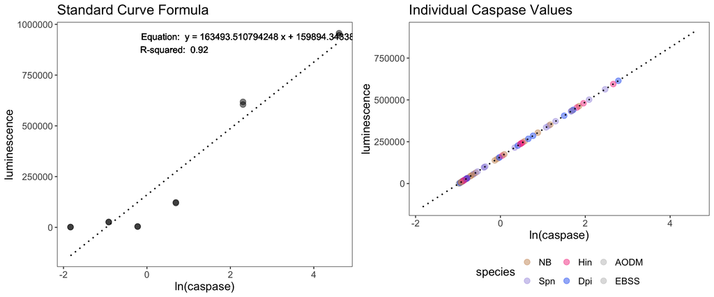

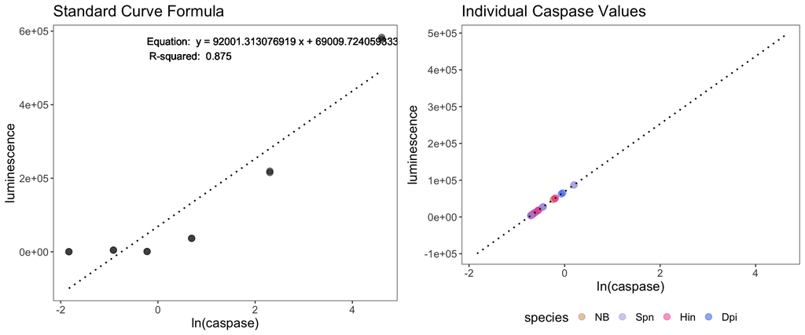

```r
results_list <- mapply(analyze_lum_data, data_list, names(data_list), SIMPLIFY = F)
```

```r
# Combine all samples into a single dataframe
all_samples <- bind_rows(lapply(results_list, `[[`, "samples"), .id = "batchID")
```

```r
# Save data frame as CSV and R object in the dataframes folder
dataframeID <- "RSVbac"
write_csv(all_samples, file.path(dataframes_folder, paste0(dataframeID, "_Caspase_values.csv")))
saveRDS(all_samples, file.path(dataframes_folder,  paste0(dataframeID, "_Caspase_values.rds")))

# Use this to read the final objects
all_samples <- readRDS(file.path(dataframes_folder, paste0(dataframeID, "_Caspase_values.rds")))

# Average technical replicates
avg_data <- all_samples %>%
  group_by(date, line, timeinf, species, virus, Combined, bacteria_label) %>%
  summarise(conc = mean(NewCaspase)) %>%
  ungroup()
```

## Stats and Plots for samples at 4 dpvi

```r
# Filter out the media control values
avg_data_4 <- avg_data %>%
  filter(timeinf == "4") %>%
  droplevels()
```

### Statistics

Analysis with a mixed-effects model with random effects for `line` and `date` and the interaction of fixed effects for `species` and the `virus` combined condition. If the model is singular, it is rerun with only `date` as random effect. The contrasts are calculated using emmeans with Holm adjustment for the virus comparisons for each bacteria. Predicted values are backtransformed to CFU scale for plotting.

Highlighted contrasts are those with a cutoff p-value of 0.05.

```r
# Function to analyze the data and plot stats
analysis_function <- function(data, cutoff_pvalue, cutoff_FC) {

  # Mixed-effects model with random effects
  model <- lmer(log(conc) ~ species * virus
                + (1|line) + (1|line:date),
                data = data)

  # Extract random effects data and convert to dataframe
  singular = isSingular(model)
  random_effects_df <- as.data.frame(VarCorr(model)) %>%
    mutate(proportion = round(100 * (vcov / sum(vcov)), 2)) %>%
    mutate(singular = singular)

  # If model is singular, rerun with only date as random effect
  if (singular) {
    model <- lmer(log(conc) ~ species * virus
                  + (1|date),
                  data = data)
  }

  # Run ANOVA and extract pvalues
  anova <- anova(model)
  anova_df <- as.data.frame(anova)

  # Extract fixed effects coefficients and convert to dataframe
  fixed_effects_df <- as.data.frame(summary(model)$coefficients) %>%
    rownames_to_column(var = "term")

  # Generate contrasts for virus comparisons within each bacteria using emmeans with Holm adjustment
  emmeans_model <- emmeans(model, ~ species * virus)
  emmeans_virus <- pairs(emmeans_model, simple = "virus", adjust = "holm")

  # Extract virus contrasts from emmeans_model and format the dataframe
  contrasts_df <- as.data.frame(summary(emmeans_virus)) %>%
    mutate(contrast = str_replace_all(contrast, "\\s+", "")) %>%
    separate(contrast, into = c("virus1", "virus2"), sep = "-") %>%
    mutate(condition1 = paste(species, virus1, sep = "."),
           condition2 = paste(species, virus2, sep = "."),
           contrast = paste(condition1, condition2, sep = " - ")) %>%
    select(-c(species, virus1, virus2)) %>%
    relocate(contrast)

  contrasts_df$group1 <- data$bacteria_label[match(contrasts_df$condition1, data$Combined)]
  contrasts_df$group2 <- data$bacteria_label[match(contrasts_df$condition2, data$Combined)]

  # Adds predictions based on fixed effects, averaged over random effects. It gives a population estimate
  data <- cbind(data, predval = predict(model,re.form = NA, se.fit = TRUE))

  # Backtransform the predicted values and CIs
  transf_preds_df <- data %>%
    group_by(Combined, bacteria_label, species, virus) %>%
    summarise(mean.predval.fit = mean(predval.fit),
              mean.predval.se.fit = mean(predval.se.fit),
              mean.conc = mean(conc),
              .groups = 'drop') %>%
    mutate(pconc = exp(mean.predval.fit),
           pconc_min = exp(mean.predval.fit - 2*mean.predval.se.fit),
           pconc_max = exp(mean.predval.fit + 2*mean.predval.se.fit)) %>%
    mutate(condition = interaction(species, virus, sep = "."))

  # Calculate fold-change values for each contrast and highlight the most relevant is pvalue < cutoff and FC > cutoff
  contrasts_df <- contrasts_df %>%
    ungroup() %>%
    left_join(select(transf_preds_df, condition, pconc), by = join_by(condition1 == condition)) %>%
    left_join(select(transf_preds_df, condition, pconc), by = join_by(condition2 == condition), suffix = c(".1", ".2")) %>%
    mutate(FC = pconc.1 / pconc.2,
           log2FC = log2(FC),
           FC = if_else(FC < 1, 1 / FC, -FC),
           highlighted = case_when(
             p.value < cutoff_pvalue & abs(log2FC) >= cutoff_FC ~ "*",
             TRUE ~ "")) %>%
    select(contrast, condition1, condition2, p.value, pconc.1, pconc.2, FC, log2FC, highlighted, group1, group2)

  return(list(anova = anova,
              random_effects = random_effects_df,
              fixed_effects = fixed_effects_df,
              contrasts = contrasts_df,
              transf_preds = transf_preds_df))
}
```

```r
all_stats <- analysis_function(avg_data_4, cutoff_pvalue = 0.05, cutoff_FC = 0)
kable(all_stats$anova)
```

|  | Sum Sq | Mean Sq | NumDF | DenDF | F value | Pr(>F) |
| --- | --- | --- | --- | --- | --- | --- |
| species | 0.4021894 | 0.1340631 | 3 | 27.99994 | 0.3535979 | 0.7868694 |
| virus | 26.9524908 | 26.9524908 | 1 | 27.99994 | 71.0884763 | 0.0000000 |
| species:virus | 0.2501575 | 0.0833858 | 3 | 27.99994 | 0.2199341 | 0.8817301 |

```r
kable(all_stats$random_effects)
```

| grp | var1 | var2 | vcov | sdcor | proportion | singular |
| --- | --- | --- | --- | --- | --- | --- |
| line:date | (Intercept) | NA | 0.0031961 | 0.0565344 | 0.68 | FALSE |
| line | (Intercept) | NA | 0.0911494 | 0.3019095 | 19.25 | FALSE |
| Residual | NA | NA | 0.3791401 | 0.6157435 | 80.07 | FALSE |

```r
kable(all_stats$fixed_effects)
```

| term | Estimate | Std. Error | df | t value | Pr(>\|t\|) |
| --- | --- | --- | --- | --- | --- |
| (Intercept) | 1.2933904 | 0.3498347 | 4.518362 | 3.6971474 | 0.0168281 |
| speciesSpn | 0.1477809 | 0.3894304 | 27.999937 | 0.3794795 | 0.7071947 |
| speciesHin | -0.0502572 | 0.3894304 | 27.999937 | -0.1290531 | 0.8982382 |
| speciesDpi | -0.0848277 | 0.3894304 | 27.999937 | -0.2178251 | 0.8291450 |
| virusT | 1.3871569 | 0.3894304 | 27.999937 | 3.5620150 | 0.0013412 |
| speciesSpn:virusT | 0.2673291 | 0.5507377 | 27.999937 | 0.4854017 | 0.6311680 |
| speciesHin:virusT | 0.3213191 | 0.5507377 | 27.999937 | 0.5834339 | 0.5642717 |
| speciesDpi:virusT | 0.4296097 | 0.5507377 | 27.999937 | 0.7800622 | 0.4418989 |

```r
kable(all_stats$contrasts %>% select(-group1, -group2, -condition1, -condition2))
```

| contrast | p.value | pconc.1 | pconc.2 | FC | log2FC | highlighted |
| --- | --- | --- | --- | --- | --- | --- |
| NB.F - NB.T | 0.0013412 | 3.645124 | 14.59308 | 4.003452 | -2.001244 | * |
| Spn.F - Spn.T | 0.0002151 | 4.225643 | 22.10176 | 5.230391 | -2.386919 | * |
| Hin.F - Hin.T | 0.0001477 | 3.466458 | 19.13672 | 5.520542 | -2.464810 | * |
| Dpi.F - Dpi.T | 0.0000693 | 3.348668 | 20.60079 | 6.151935 | -2.621040 | * |

```r
saveRDS(all_stats, file.path(outputs_folder,  paste0(dataframeID, "_Caspase_stats.rds")))
```

### Plots

```r
# Function to plot the CFUs using the statistical model
plot_function <- function(true_data, stats_data, contrasts, ymax) {

  # Plot
  plot <- ggplot() +

    geom_jitter(data = true_data,
                aes(x = bacteria_label, y = conc, color = species,
                    shape = line),
                width = 0.2, size = 3, alpha = 0.85, stroke = 0.75, show.legend = TRUE) +

    scale_color_manual(values = Bac.colors) +
    scale_shape_manual(values = c(19,17)) +

    scale_y_log10(breaks = trans_breaks("log10", function(x) 10^x),
                  labels = trans_format("log10", math_format(10^.x))) +

    geom_point(data = stats_data, aes(x = bacteria_label, y = pconc), shape = 3, size = 3) +
    geom_errorbar(data = stats_data, width = 0.5,
                  aes(x = bacteria_label, y = pconc, ymax = pconc_max, ymin = pconc_min)) +

    # General style
    scale_x_discrete(expand = c(0,0.5)) +
    labs(x = "",
         y = "Caspase (total units)",
         caption = paste("RSV", "Bact", "DPVI", sep = "\n"),
         color = "Bacteria", color = "Bacteria", shape = "HNO Line") +
    theme_bw() +
    theme(panel.grid = element_blank(),
          legend.text = element_markdown(),
          text = element_text(size = 18, color = "black"),
          plot.caption = element_text(size = 13, face = "bold", hjust = -0.13, vjust = 24),
          axis.text.x = element_markdown(),
          axis.text.y = element_text(color = "black"),
          plot.margin = unit(c(0.1,0.1,-0.8,0.1), "in"))

  # Add significance asterisks for highlighted contrasts
  contrast_sign <- contrasts %>%
    filter(highlighted != "") %>%
    mutate(plot = "*")

  if (nrow(contrast_sign) > 0) {
    plot <- plot +
      stat_pvalue_manual(contrast_sign, label = "plot", y.position = ymax,
                         step.increase = 0.03, tip.length = 0.01, bracket.shorten = 0.2, vjust = 0.6, bracket.size = 0.5)
  }

  return(plot)
}
```

```r
# This plot was not used in the manuscript
Caspase_plot <- plot_function(true_data = avg_data_4, stats_data = all_stats$transf_preds, contrasts = all_stats$contrasts, ymax = 1.6)
```

```r
boxplot <- ggplot(avg_data_4, aes(x = bacteria_label, y = conc)) +
  geom_boxplot(outliers = F ) +
  geom_jitter(aes(x = bacteria_label, y = conc, color = species, shape = line),
              width = 0.2, size = 3, alpha = 0.85, stroke = 0.75, show.legend = TRUE) +
  geom_hline(yintercept = 0.16*8, linetype = "dashed", color = "black", linewidth = 0.8) +
  scale_color_manual(values = Bac.colors) +
  scale_y_log10(limits = c(NA, 10^2),
                breaks = 10^(0:2),
                labels = trans_format("log10", math_format(10^.x))) +
  labs(x = "",
       y = "Caspase units / organoid",
       caption = paste("RSV", "Bact", "DPVI", sep = "\n"),
       color = "Bacteria", shape = "HNO Line") +
  theme_bw() +
  theme(panel.grid = element_blank(),
        text = element_text(size = 18, color = "black"),
        plot.caption = element_text(size = 13, face = "bold", hjust = -0.13, vjust = 24),
        axis.text.x = element_markdown(),
        axis.text.y = element_text(color = "black"),
        plot.margin = unit(c(0.1,0.1,-0.8,0.1), "in"))
```

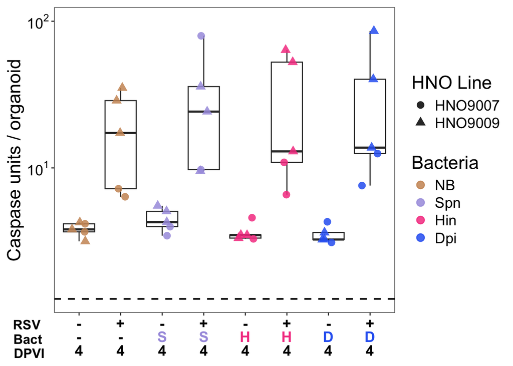

```r
boxplot
```

```r
ggsave(boxplot, filename = file.path(outputs_folder,  paste0(dataframeID, "_BoxplotCaspase.png")), width = 7, height = 5)
saveRDS(boxplot, file = file.path(outputs_folder,  paste0(dataframeID, "_BoxplotCaspase.rds")))
```